# Lesson 5

### Multivariate Data

Notes:

### Moira Perceived Audience Size Colored by Age

Notes:

### Third Qualitative Variable

Notes: We add gender variable

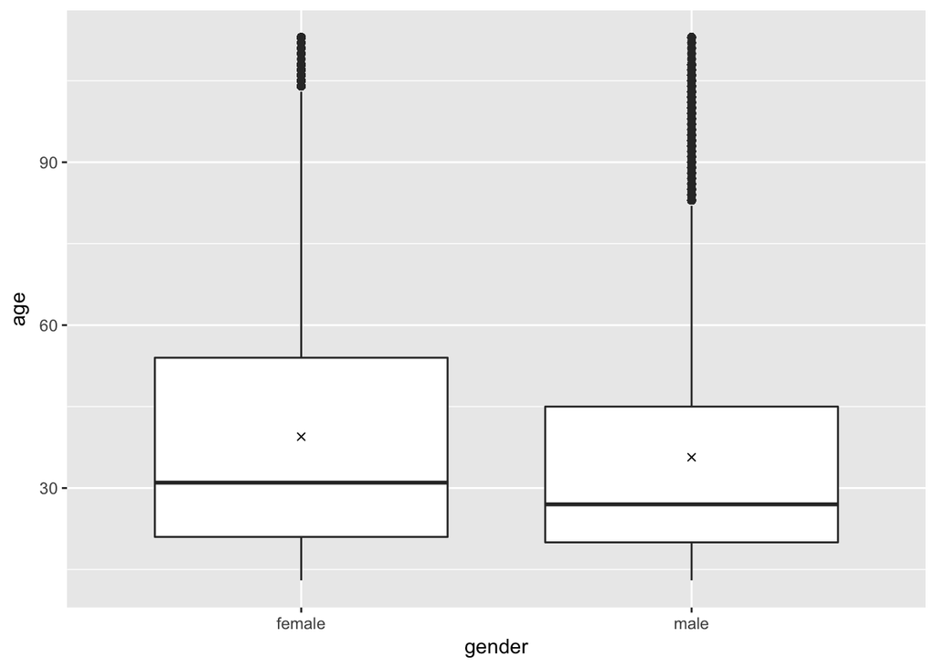

```r
library(ggplot2)
pf <- read.csv('pseudo_facebook.tsv', sep = '\t')
ggplot(aes(x = gender, y = age),
       data = subset(pf, !is.na(gender))) + geom_boxplot() +
  #before:  geom_line(stat = 'summary', fun.y = quantile, fun.args = list(probs = .1), linetype = 2, color= 'blue')
  #shape = 4 is an x
  stat_summary(fun.y = mean, geom = 'point', shape = 4)
```

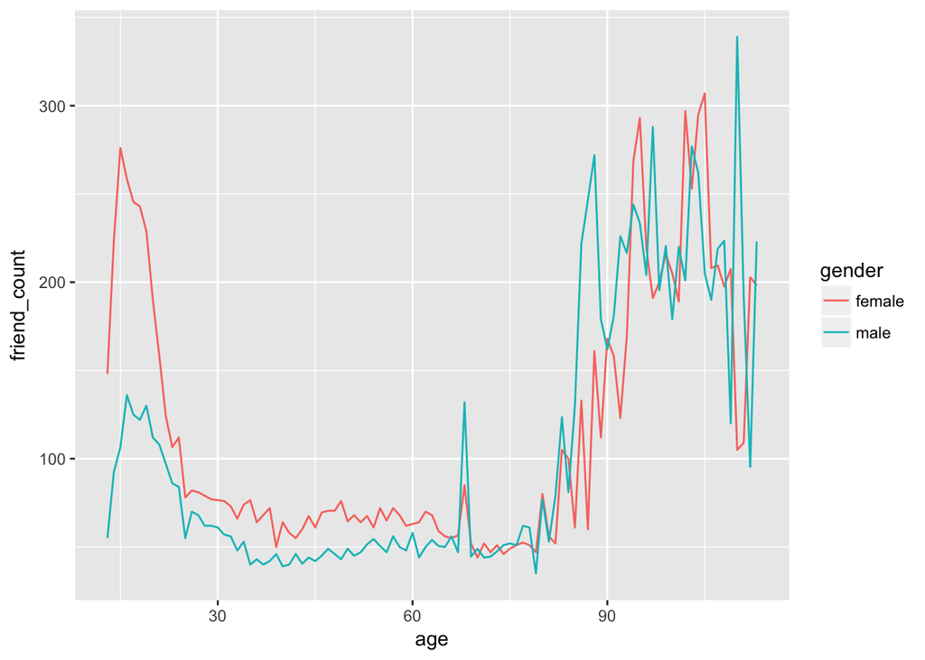

```r
ggplot(aes(x = age, y = friend_count),
       #omitting those with non available gender
       data = subset(pf, !is.na(gender))) +
  geom_line(aes(color = gender), stat = 'summary', fun.y = median)
```

```r
#ggplot(aes(x = age, y = median_friend_count),
#       data = subset(pf.fc_by_age_gender, !is.na(gender))) +
#  geom_line(aes(color = gender))
```

```r
# Write code to create a new data frame,
# called 'pf.fc_by_age_gender', that contains
# information on each age AND gender group.

# The data frame should contain the following variables:

#    mean_friend_count,
#    median_friend_count,
#    n (the number of users in each age and gender grouping)

# Here is an example of the structure of your data frame. Your
# data values will be different. Note that if you are grouping by
# more than one variable, you will probably need to call the
# ungroup() function.

#   age gender mean_friend_count median_friend_count    n
# 1  13 female          247.2953                 150  207
# 2  13   male          184.2342                  61  265
# 3  14 female          329.1938                 245  834
# 4  14   male          157.1204                  88 1201

pf <- read.delim('pseudo_facebook.tsv')
suppressMessages(library(dplyr))
pf.fc_by_age_gender <- pf %>%
  filter(!is.na(gender)) %>% #instead of subsetting we use filters
  group_by(age, gender) %>%
  summarise(mean_friend_count = mean(friend_count),
            median_friend_count = median(as.numeric(friend_count)),
            n = n()) %>%
  ungroup() %>% #ungrouping doesn't change the data - it changes the container type, from a grouped_df to a dataframe.
  arrange (age, gender)

class(pf.fc_by_age_gender)
```

```
## [1] "tbl_df"     "tbl"        "data.frame"
```

```r
head(pf.fc_by_age_gender)
```

```
## # A tibble: 6 x 5
##     age gender mean_friend_count median_friend_count     n
##   <int> <fctr>             <dbl>               <dbl> <int>
## 1    13 female          259.1606               148.0   193
## 2    13   male          102.1340                55.0   291
## 3    14 female          362.4286               224.0   847
## 4    14   male          164.1456                92.5  1078
## 5    15 female          538.6813               276.0  1139
## 6    15   male          200.6658               106.5  1478
```

```r
# group_by creates a grouped_df. If you group by one variable and apply summarise, the result will be a df. But if you group by two variables the summarise operation won´t change it back to dataframe, you have to ungroup it if you want.
```

Remember: Important Notice! Please note that in newer versions of dplyr (0.3.x+), the syntax %.% has been deprecated and replaced with %>%. Videos in the course use %.%, which will produce warning messages. If you answer using the chain operator, you should use %>% instead.

Another warning: Version 0.4.0 of dplyr has a bug when using the median function on the summarize layer, depending on the nature of the data being summarized. You may need to cast the data as a numeric (float) type to get the expected results, e.g. median(as.numeric(var)).

You can include multiple variables to split the data frame when using group_by() function in the dplyr package.

new_groupings <- group_by(data, variable1, variable2)

OR using chained commands…

new_data_frame <- data_frame %>% group_by(variable1, variable2) %>%

### Plotting Conditional Summaries

Notes:

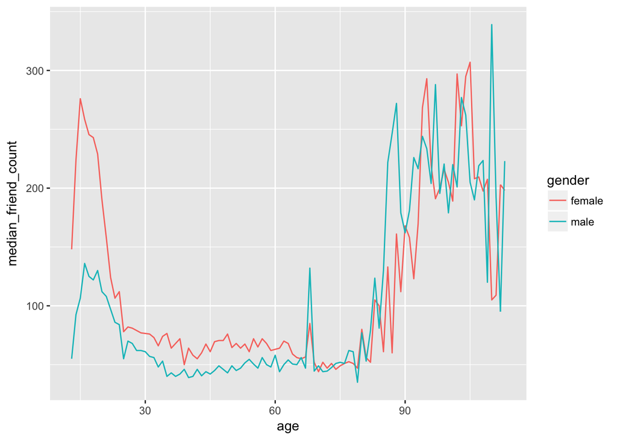

```r
# Now we are obtaining the same graph than before using the new fc_by_age_gender grouping
ggplot(aes(x = age, y = median_friend_count),
       data = subset(pf.fc_by_age_gender, !is.na(gender))) +
  geom_line(aes(color = gender))
```

### Thinking in Ratios

Notes: The question would be how many times more friends does the average female user have than the male user.

### Wide and Long Format

Notes: To answer the previous question we need to rearrange the data a little bit. Rigth now we have long format (many rows and variables age and gender are repeated) LONG FORMAT age gender mean_friend_count median_friend_count n 13 female 259.1606 148.0 193 13 male 102.1340 55.0 291 14 female 362.4286 224.0 847 14 male 164.1456 92.5 1078

WIDE FORMAT for mean_friend_count age male female 13 102.1340 259.1606 14 164.1456 362.4286

to make this rearrangements we will be using the Reshape2 package ***

### Reshaping Data

Notes:Reshape or tydir for reshaping

```r
#reshape is mor complex than tidyr
#install.packages('reshape2')
library(reshape2)
# we are creating a new variable named fc_by_age_gender.wide
# we use dcast (from reshape2) because we want a datafram, acast would be for arrays and so on -> long to wide
# Nill function to convert back from wide to long.
# age ~ gender, on the left the var I want to keep, on the left the one that is going to be extended into two columns

pf.fc_by_age_gender.wide <- dcast(pf.fc_by_age_gender,
                                  age ~ gender,
                                  value.var = 'median_friend_count')
head(pf.fc_by_age_gender.wide)
```

```
##   age female  male
## 1  13  148.0  55.0
## 2  14  224.0  92.5
## 3  15  276.0 106.5
## 4  16  258.5 136.0
## 5  17  245.5 125.0
## 6  18  243.0 122.0
```

```r
head(pf)
```

```
##    userid age dob_day dob_year dob_month gender tenure friend_count
## 1 2094382  14      19     1999        11   male    266            0
## 2 1192601  14       2     1999        11 female      6            0
## 3 2083884  14      16     1999        11   male     13            0
## 4 1203168  14      25     1999        12 female     93            0
## 5 1733186  14       4     1999        12   male     82            0
## 6 1524765  14       1     1999        12   male     15            0
##   friendships_initiated likes likes_received mobile_likes
## 1                     0     0              0            0
## 2                     0     0              0            0
## 3                     0     0              0            0
## 4                     0     0              0            0
## 5                     0     0              0            0
## 6                     0     0              0            0
##   mobile_likes_received www_likes www_likes_received
## 1                     0         0                  0
## 2                     0         0                  0
## 3                     0         0                  0
## 4                     0         0                  0
## 5                     0         0                  0
## 6                     0         0                  0
```

```r
# pf.fc_by_age_gender is just the name of the variable we are creating
head(pf.fc_by_age_gender)
```

```
## # A tibble: 6 x 5
##     age gender mean_friend_count median_friend_count     n
##   <int> <fctr>             <dbl>               <dbl> <int>
## 1    13 female          259.1606               148.0   193
## 2    13   male          102.1340                55.0   291
## 3    14 female          362.4286               224.0   847
## 4    14   male          164.1456                92.5  1078
## 5    15 female          538.6813               276.0  1139
## 6    15   male          200.6658               106.5  1478
```

```r
head(pf.fc_by_age_gender.wide)
```

```
##   age female  male
## 1  13  148.0  55.0
## 2  14  224.0  92.5
## 3  15  276.0 106.5
## 4  16  258.5 136.0
## 5  17  245.5 125.0
## 6  18  243.0 122.0
```

```r
class(pf)
```

```
## [1] "data.frame"
```

```r
class(pf.fc_by_age_gender)
```

```
## [1] "tbl_df"     "tbl"        "data.frame"
```

```r
class(pf.fc_by_age_gender.wide)
```

```
## [1] "data.frame"
```

We can create similar data frame using the dplyr and tidyr packages:

```r
#install.packages('dplyr')
library(dplyr)
#install.packages('tidyr')
library(tidyr)
pf.fc_by_age_gender.wide <-
  subset(pf.fc_by_age_gender[c('age', 'gender', 'median_friend_count')],
         !is.na(gender)) %>%
  spread(gender, median_friend_count) %>%
  mutate(ratio = male / female)

head(pf.fc_by_age_gender.wide)
```

```
## # A tibble: 6 x 4
##     age female  male     ratio
##   <int>  <dbl> <dbl>     <dbl>
## 1    13  148.0  55.0 0.3716216
## 2    14  224.0  92.5 0.4129464
## 3    15  276.0 106.5 0.3858696
## 4    16  258.5 136.0 0.5261122
## 5    17  245.5 125.0 0.5091650
## 6    18  243.0 122.0 0.5020576
```

### Ratio Plot

Notes:

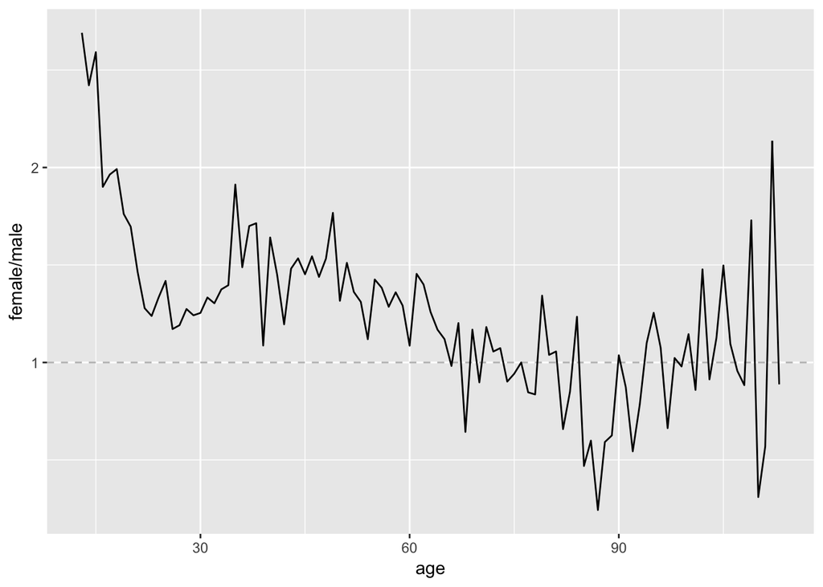

```r
# Plot the ratio of the female to male median
# friend counts using the data frame
# pf.fc_by_age_gender.wide.

# Think about what geom you should use.
# Add a horizontal line to the plot with
# a y intercept of 1, which will be the
# base line. Look up the documentation
# for geom_hline to do that. Use the parameter
# linetype in geom_hline to make the
# line dashed.

# The linetype parameter can take the values 0-6:
# 0 = blank, 1 = solid, 2 = dashed
# 3 = dotted, 4 = dotdash, 5 = longdash
# 6 = twodash
library(ggplot2)

ggplot(aes(x = age, y = female/male), data = pf.fc_by_age_gender.wide) +
  geom_line() +
  geom_hline(yintercept = 1, alpha = 0.3, linetype = 2)
```

### Third Quantitative Variable

Notes: Four variables: friend_count, age, gender, tenure (how many days since sign up for facebook)

```r
# Create a variable called year_joined
# in the pf data frame using the variable
# tenure and 2014 as the reference year.

# The variable year joined should contain the year
# that a user joined facebook.
pf$year_joined <- floor(2014 - (pf$tenure/365))
summary(pf$year_joined)
```

```
##    Min. 1st Qu.  Median    Mean 3rd Qu.    Max.    NA's
##    2005    2012    2012    2012    2013    2014       2
```

```r
table(pf$year_joined)
```

```
##
##  2005  2006  2007  2008  2009  2010  2011  2012  2013  2014
##     9    15   581  1507  4557  5448  9860 33366 43588    70
```

Cut function is useful to create discreet variables from continuous or numerical ones.Sometimes in combination with function quartile. ***

### Cut a Variable

Notes:

```r
# Create a new variable in the data frame
# called year_joined.bucket by using
# the cut function on the variable year_joined.

# You need to create the following buckets for the
# new variable, year_joined.bucket

#        (2004, 2009]
#        (2009, 2011]
#        (2011, 2012]
#        (2012, 2014]

# Note that a parenthesis means exclude the year and a
# bracket means include the year.

pf$year_joined.bucket <- cut(pf$year_joined,
                             c(2004, 2009, 2011, 2012, 2014))
table(pf$year_joined.bucket, useNA = 'ifany')
```

```
##
## (2004,2009] (2009,2011] (2011,2012] (2012,2014]        <NA>
##        6669       15308       33366       43658           2
```

### Plotting it All Together

Notes:

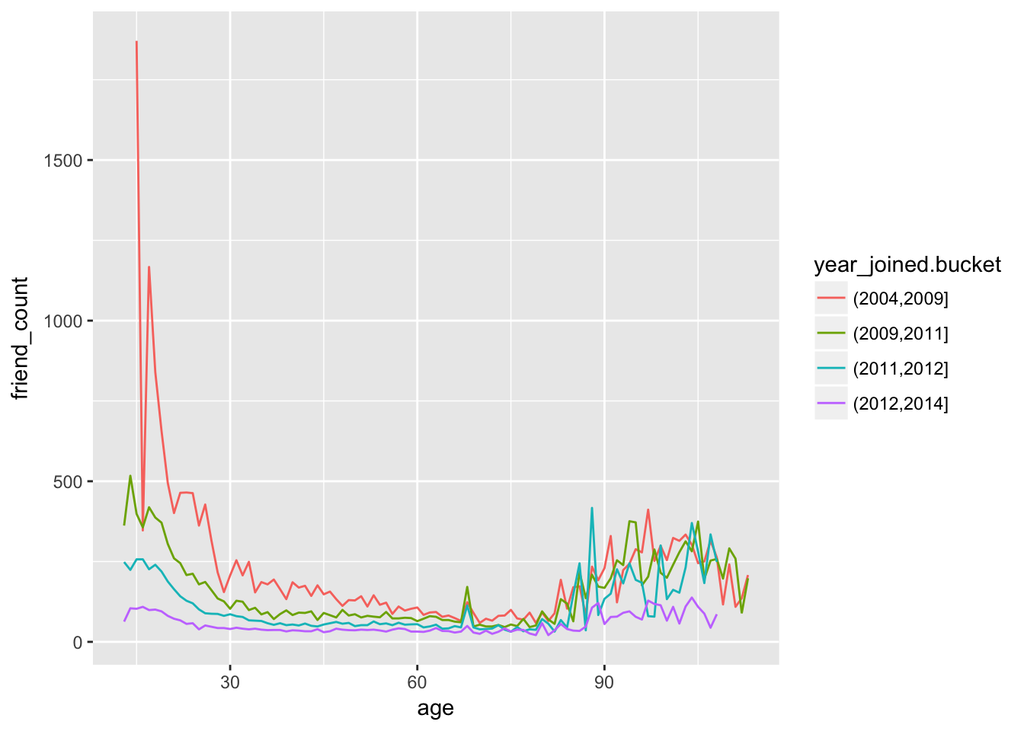

```r
#before we used
#ggplot(aes(x = age, y = friend_count),
#       data = subset(pf, !is.na(gender))) +
#  geom_line(aes(color = gender), stat = 'summary', fun.y = median)

# Create a line graph of friend_count vs. age
# so that each year_joined.bucket is a line
# tracking the median user friend_count across
# age. This means you should have four different
# lines on your plot.

# You should subset the data to exclude the users
# whose year_joined.bucket is NA.
ggplot(aes(x = age, y = friend_count),
       data = subset(pf, !is.na(year_joined.bucket))) +
  geom_line(aes(color = year_joined.bucket), stat ='summary', fun.y = median)
```

### Plot the Grand Mean

Notes: Grand Mean is average friend count across the ages.

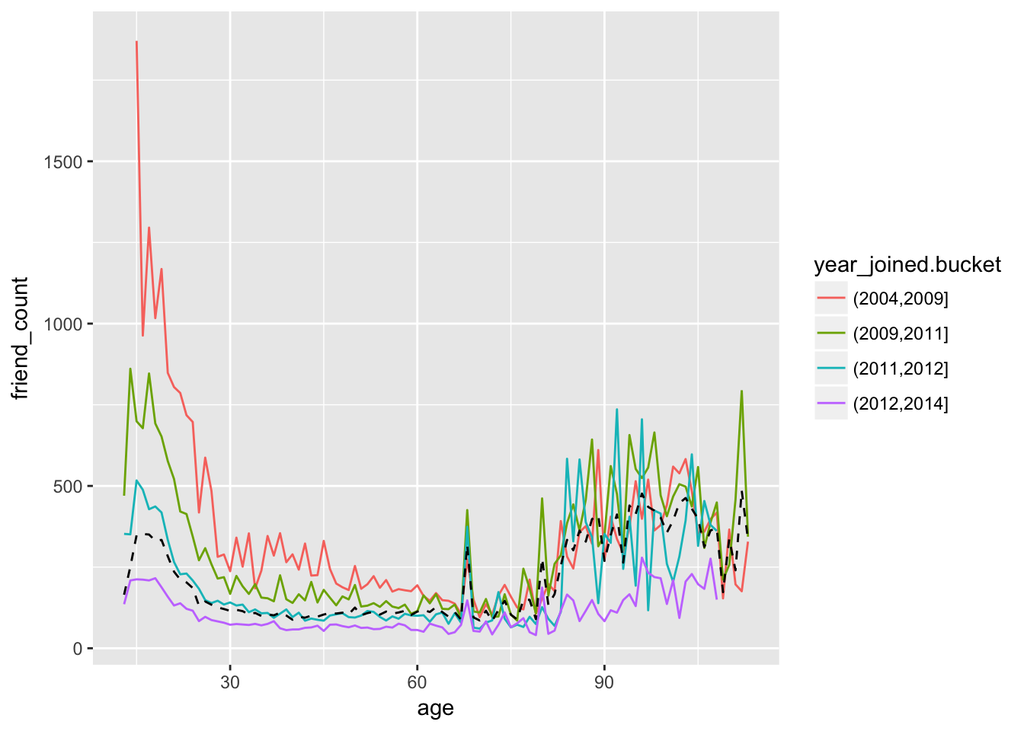

```r
# Write code to do the following:

# (1) Add another geom_line to code below
# to plot the grand mean of the friend count vs age.

# (2) Exclude any users whose year_joined.bucket is NA.

# (3) Use a different line type for the grand mean.

# As a reminder, the parameter linetype can take the values 0-6:

# 0 = blank, 1 = solid, 2 = dashed
# 3 = dotted, 4 = dotdash, 5 = longdash
# 6 = twodash
ggplot(aes(x = age, y = friend_count),
       data = subset(pf, !is.na(year_joined.bucket))) +
  geom_line(aes(color = year_joined.bucket), stat ='summary', fun.y = mean) +
  geom_line(linetype = 2, stat = 'summary', fun.y = mean)
```

### Friending Rate

Notes:

```r
with(subset(pf, tenure >= 1), summary(friend_count/tenure))
```

```
##     Min.  1st Qu.   Median     Mean  3rd Qu.     Max.
##   0.0000   0.0775   0.2205   0.6096   0.5658 417.0000
```

### Friendships Initiated

Notes:

What is the median friend rate? 0.2205

What is the maximum friend rate? 417 it is an outlier taking into account the 3rd Qu value

```
## No summary function supplied, defaulting to `mean_se()
```

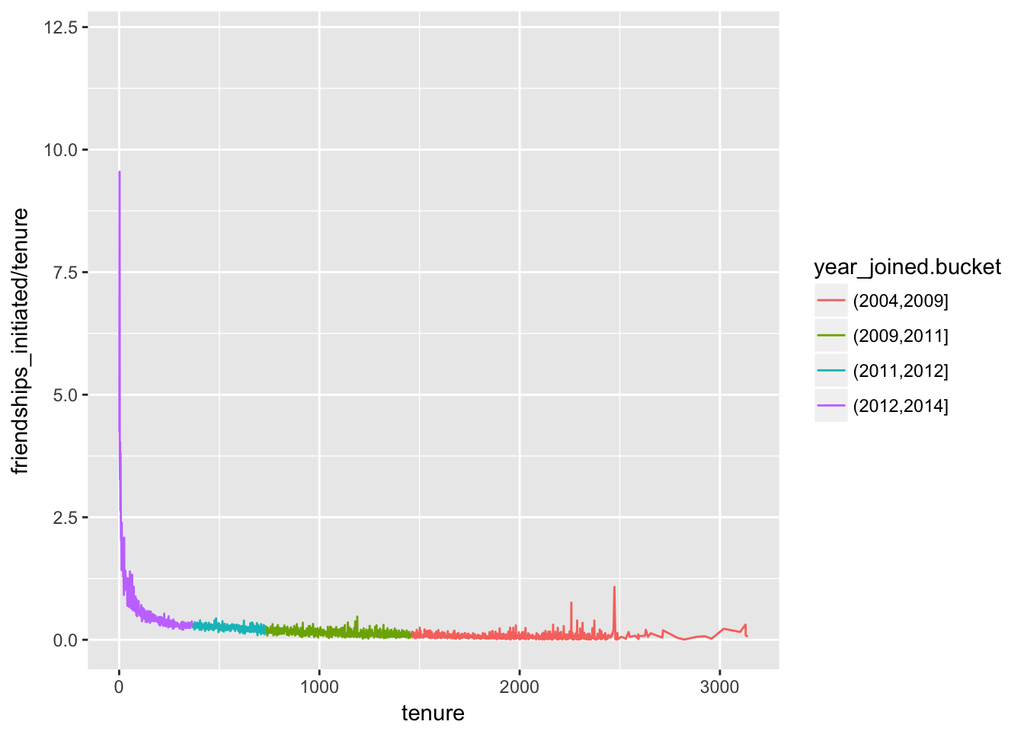

```r
# Create a line graph of mean of friendships_initiated per day (of tenure)
# vs. tenure colored by year_joined.bucket.

# You need to make use of the variables tenure,
# friendships_initiated, and year_joined.bucket.

# You also need to subset the data to only consider user with at least
# one day of tenure.
ggplot(aes(x = tenure, y = friendships_initiated/tenure),
       data = subset(pf, tenure >= 1)) +
  geom_line(aes(color = year_joined.bucket), stat = 'summary', func.y = mean)
```

### Bias-Variance Tradeoff Revisited

Notes: To reduce the noise from previous graph: x = 7 * round(tenure / 7) instead of tenure binning values by the denominator in the round function and then transforming back to the natural scale with the constant in front. WE ARE MAKING THE X VALUES BETWEEN 0 AND 7 TO DISAPPEAR, SO WE ARE PAINTING ONE VALUE OUT OF 7. Is this a MOVING AVERAGE? Well, since we are calculating the mean of all the friendships_initiated in the 7th day, we are not doing the mean of a series of values, I don’t think this is a moving average.

When we take one value out of 7 and then one out of 30, we are reducing the variance (hence the variance noise) but we are including the bias (sesgo) (hence the bias noise). We need a balance.

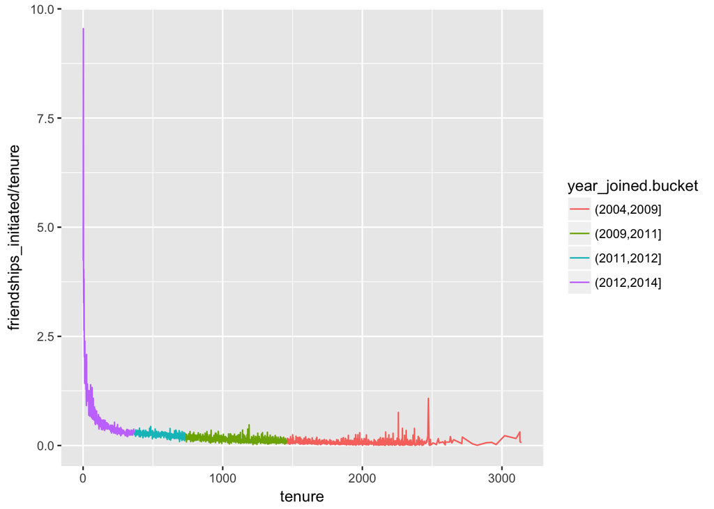

```r
ggplot(aes(x = tenure, y = friendships_initiated / tenure),
       data = subset(pf, tenure >= 1)) +
  geom_line(aes(color = year_joined.bucket),
            stat = 'summary',
            fun.y = mean)
```

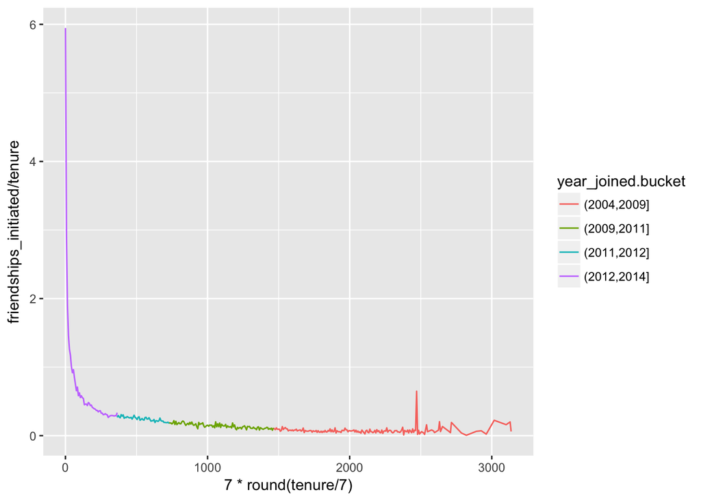

```r
ggplot(aes(x = 7 * round(tenure / 7), y = friendships_initiated / tenure),
       data = subset(pf, tenure > 0)) +
  geom_line(aes(color = year_joined.bucket),
            stat = "summary",
            fun.y = mean)
```

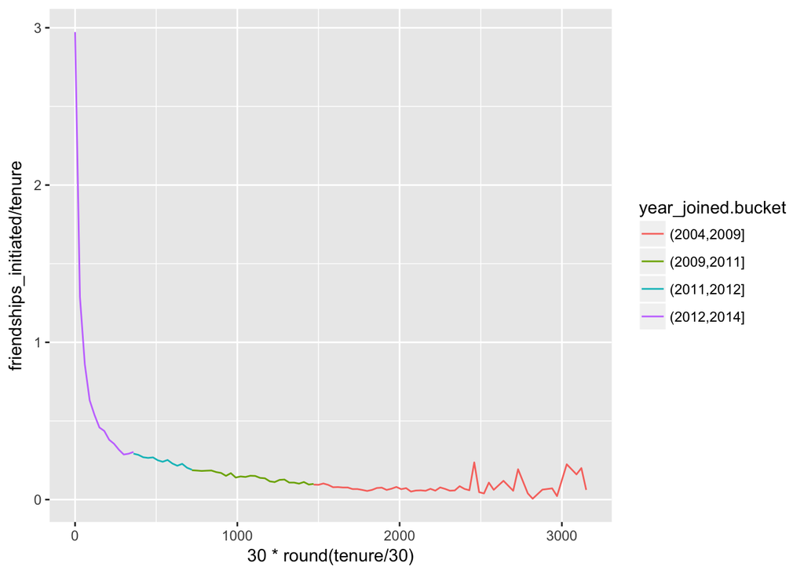

```r
ggplot(aes(x = 30 * round(tenure / 30), y = friendships_initiated / tenure),
       data = subset(pf, tenure > 0)) +
  geom_line(aes(color = year_joined.bucket),
            stat = "summary",
            fun.y = mean)
```

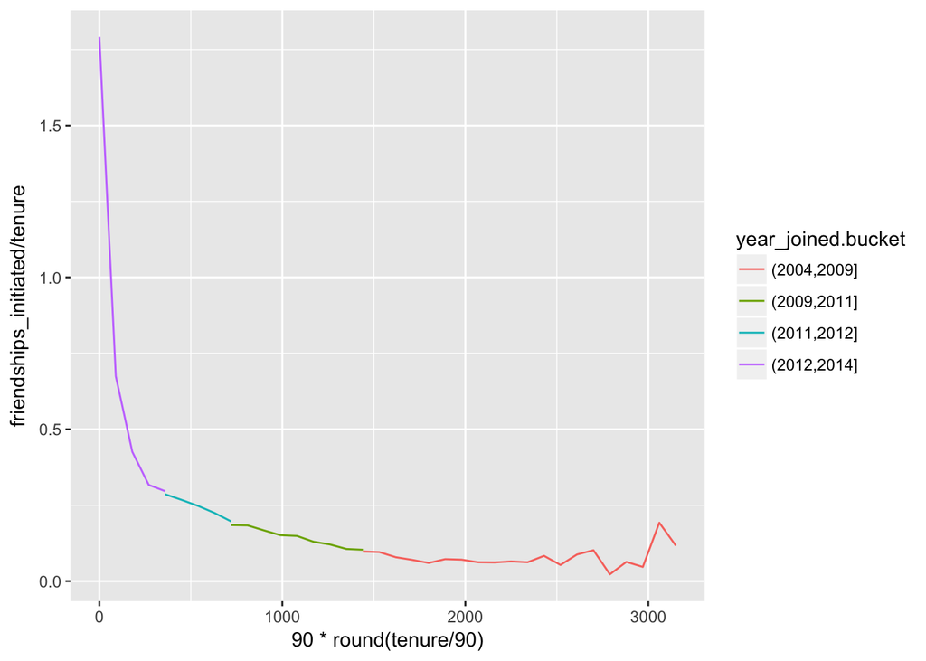

```r
ggplot(aes(x = 90 * round(tenure / 90), y = friendships_initiated / tenure),
       data = subset(pf, tenure > 0)) +
  geom_line(aes(color = year_joined.bucket),
            stat = "summary",
            fun.y = mean)
```

Using geom_smooth for smoothing the noise.

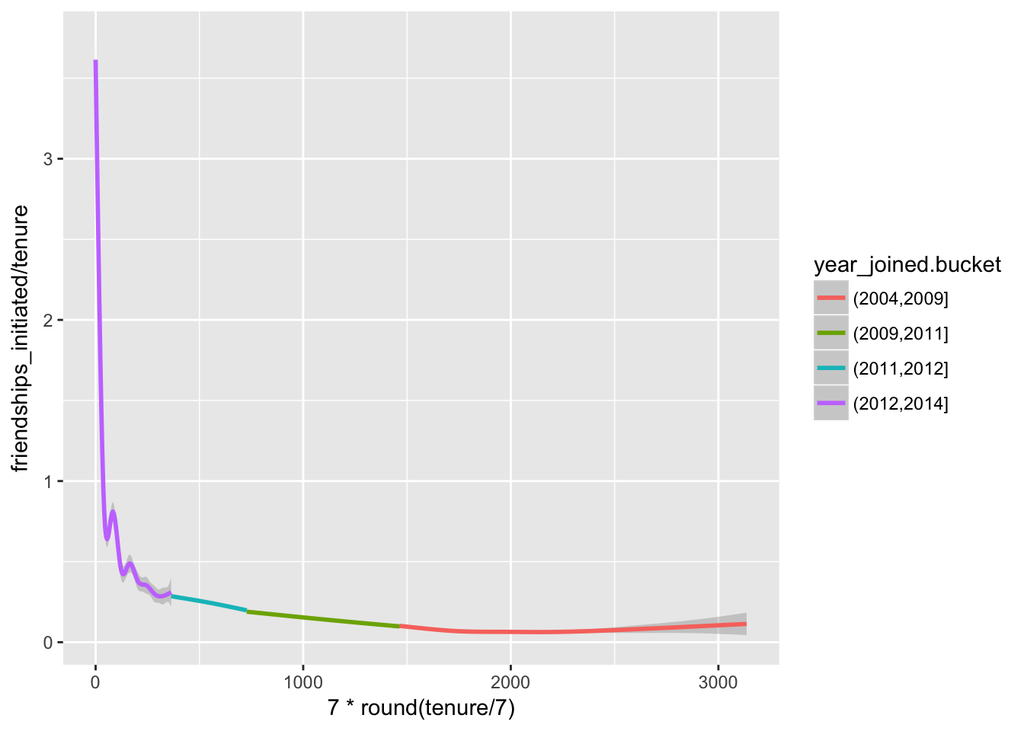

```r
# Instead of geom_line(), use geom_smooth() to add a smoother to the plot.
# You can use the defaults for geom_smooth() but do color the line
# by year_joined.bucket
ggplot(aes(x = 7 * round(tenure / 7), y = friendships_initiated / tenure),
       data = subset(pf, tenure > 0)) +
  geom_smooth(aes(color = year_joined.bucket))
```

NOTE:Review [Understanding the Bias-Variance Tradeoff](http://scott.fortmann-roe.com/docs/BiasVariance.html)

### Sean’s NFL Fan Sentiment Study

Notes: He calculates the ratios of positive over negative words, first at five minute increments over the course of 4 months. Then calculates the moving average for one hour,for one day and finally for 7 days. Combines smoothing with splines with the moving average over 7 days to find what he wanted to show. Splines is an interpolation technique, while the moving average is dropping values, extrapoling. The longest the period, the smallest the variance but the biggest the bias. A balance is necessary.

### Introducing the Yogurt Data Set

Notes: 5 flavors of dannon yogurt. It is micro data since we have a line in the dataset for each of the purchases.

```r
yo <- read.csv('yogurt.csv')
str(yo)
```

```
## 'data.frame':    2380 obs. of  9 variables:
##  $ obs        : int  1 2 3 4 5 6 7 8 9 10 ...
##  $ id         : int  2100081 2100081 2100081 2100081 2100081 2100081 2100081 2100081 2100081 2100081 ...
##  $ time       : int  9678 9697 9825 9999 10015 10029 10036 10042 10083 10091 ...
##  $ strawberry : int  0 0 0 0 1 1 0 0 0 0 ...
##  $ blueberry  : int  0 0 0 0 0 0 0 0 0 0 ...
##  $ pina.colada: int  0 0 0 0 1 2 0 0 0 0 ...
##  $ plain      : int  0 0 0 0 0 0 0 0 0 0 ...
##  $ mixed.berry: int  1 1 1 1 1 1 1 1 1 1 ...
##  $ price      : num  59 59 65 65 49 ...
```

```r
# change the id from an int to a factor
yo$id <- factor(yo$id)
str(yo)
```

```
## 'data.frame':    2380 obs. of  9 variables:
##  $ obs        : int  1 2 3 4 5 6 7 8 9 10 ...
##  $ id         : Factor w/ 332 levels "2100081","2100370",..: 1 1 1 1 1 1 1 1 1 1 ...
##  $ time       : int  9678 9697 9825 9999 10015 10029 10036 10042 10083 10091 ...
##  $ strawberry : int  0 0 0 0 1 1 0 0 0 0 ...
##  $ blueberry  : int  0 0 0 0 0 0 0 0 0 0 ...
##  $ pina.colada: int  0 0 0 0 1 2 0 0 0 0 ...
##  $ plain      : int  0 0 0 0 0 0 0 0 0 0 ...
##  $ mixed.berry: int  1 1 1 1 1 1 1 1 1 1 ...
##  $ price      : num  59 59 65 65 49 ...
```

### Histograms Revisited

Notes: There is discreteness in the distribution, prices with many observations and no observations in other prices.

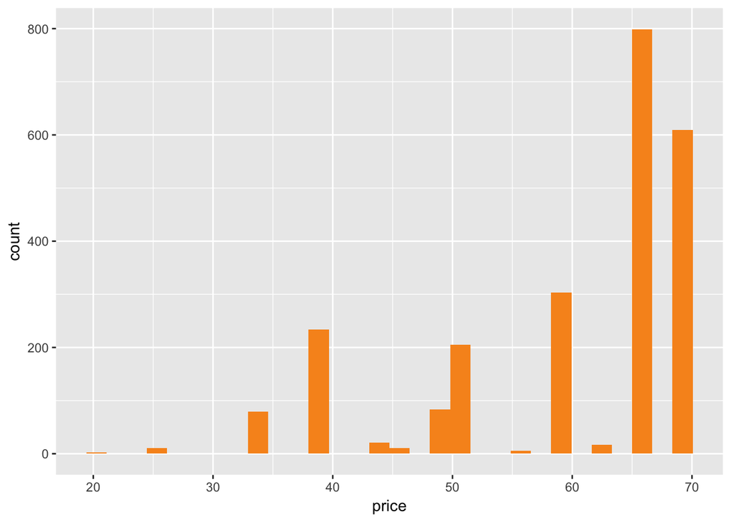

```r
qplot(x = price, data = yo, fill = I("#F79420"))
```

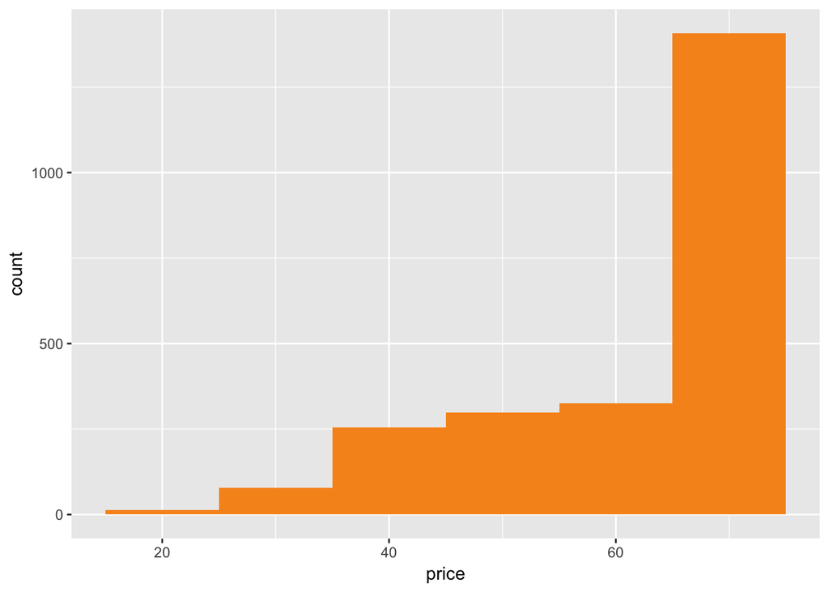

```r
qplot(x = price, data = yo, fill = I("#F79420"), binwidth = 10)
```

```r
# with a binwidth of 10 we miss the observation for the adjacent prices, second histogram is a very biased model.
```

### Number of Purchases

Notes:

```r
# we could miss information if we choose the wrong binwidth, one clue to its discreteness is that 75th percentile is the same as the maximum (prices)
summary(yo)
```

```
##       obs               id            time         strawberry
##  Min.   :   1.0   2132290:  74   Min.   : 9662   Min.   : 0.0000
##  1st Qu.: 696.5   2130583:  59   1st Qu.: 9843   1st Qu.: 0.0000
##  Median :1369.5   2124073:  50   Median :10045   Median : 0.0000
##  Mean   :1367.8   2149500:  50   Mean   :10050   Mean   : 0.6492
##  3rd Qu.:2044.2   2101790:  47   3rd Qu.:10255   3rd Qu.: 1.0000
##  Max.   :2743.0   2129528:  39   Max.   :10459   Max.   :11.0000
##                   (Other):2061
##    blueberry        pina.colada          plain         mixed.berry
##  Min.   : 0.0000   Min.   : 0.0000   Min.   :0.0000   Min.   :0.0000
##  1st Qu.: 0.0000   1st Qu.: 0.0000   1st Qu.:0.0000   1st Qu.:0.0000
##  Median : 0.0000   Median : 0.0000   Median :0.0000   Median :0.0000
##  Mean   : 0.3571   Mean   : 0.3584   Mean   :0.2176   Mean   :0.3887
##  3rd Qu.: 0.0000   3rd Qu.: 0.0000   3rd Qu.:0.0000   3rd Qu.:0.0000
##  Max.   :12.0000   Max.   :10.0000   Max.   :6.0000   Max.   :8.0000
##
##      price
##  Min.   :20.00
##  1st Qu.:50.00
##  Median :65.04
##  Mean   :59.25
##  3rd Qu.:68.96
##  Max.   :68.96
##
```

```r
#also by seeing how many distinc prices are in the dataset, only 20
length(unique(yo$price))
```

```
## [1] 20
```

```r
#tabling it we can see the distribution as we've seen in the histogram
table(yo$price)
```

```
##
##    20 24.96 33.04  33.2 33.28 33.36 33.52 39.04    44 45.04 48.96 49.52
##     2    11    54     1     1    22     1   234    21    11    81     1
##  49.6    50 55.04 58.96    62 63.04 65.04 68.96
##     1   205     6   303    15     2   799   609
```

```r
# Create a new variable called all.purchases,
# which gives the total counts of yogurt for
# each observation or household.

# One way to do this is using the transform
# function. It takes in a data frame an allows us to add different variables to it by recombining variables that already within the dataframe

yo <- transform(yo, all.purchases = strawberry + blueberry + pina.colada + plain + mixed.berry)
summary(yo$all.purchases)
```

```
##    Min. 1st Qu.  Median    Mean 3rd Qu.    Max.
##   1.000   1.000   2.000   1.971   2.000  21.000
```

```r
# alternate verbose form
yo$all.purchases <- yo$strawberry + yo$blueberry + yo$pina.colada + yo$plain + yo$mixed.berry
```

### Prices over Time

Notes:

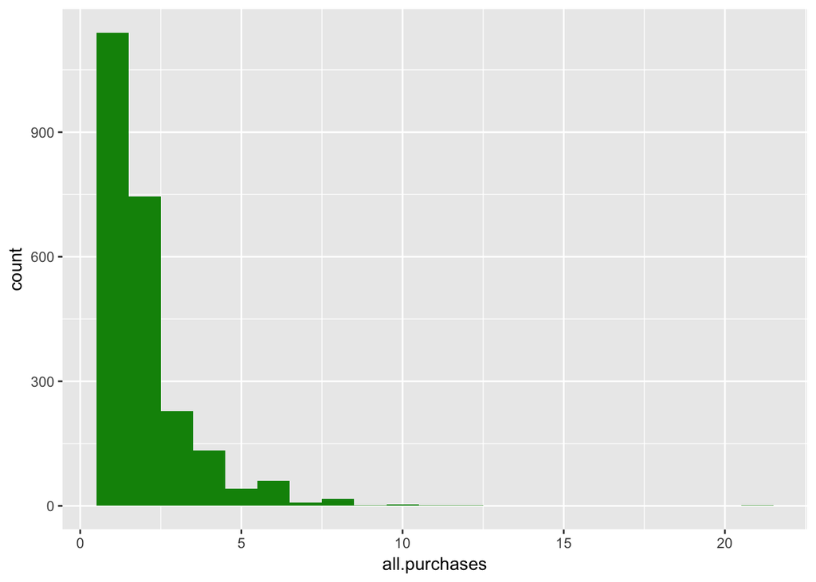

```r
qplot(x = all.purchases, data = yo, binwidth = 1, fill = I('#099009'))
```

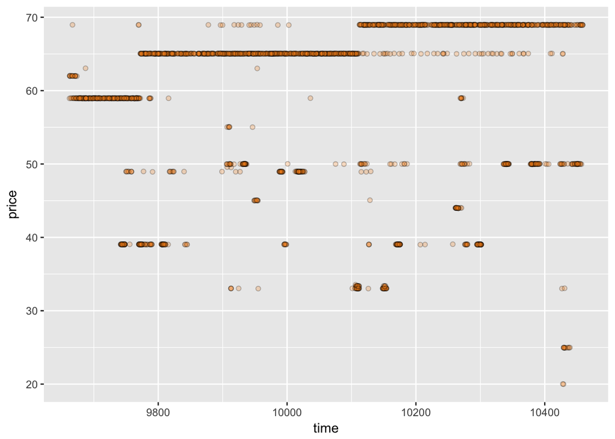

```r
ggplot(aes(x = time, y = price), data = yo) +
  #geom_point()
  # geom_jitter to add transparency
  geom_jitter(alpha = 1/4, shape = 21, fill = I('#F79420'))
```

```r
# Shape takes four types of values: an integer in [0, 25],
# a single character-- which uses that character as the plotting symbol,
# a . to draw the smallest rectangle that is visible (i.e., about one pixel)
# an NA to draw nothing
```

### Sampling Observations

Notes: When we have a dataset with multiple observations, it can be easier to work with a sample to study it.

### Looking at Samples of Households

x %in% y returns a logical (boolean) vector the same length as x that says whether each entry in x appears in y. That is, for each entry in x, it checks to see whether it is in y. This allows us to subset the data so we get all the purchases occasions for the households in the sample. Then, we create scatterplots of price vs. time and facet by the sample id.

Use the pch or shape parameter to specify the symbol when plotting points. Scroll down to ‘Plotting Points’ on (QuickR’s Graphical Parameters)[http://www.statmethods.net/advgraphs/parameters.html].

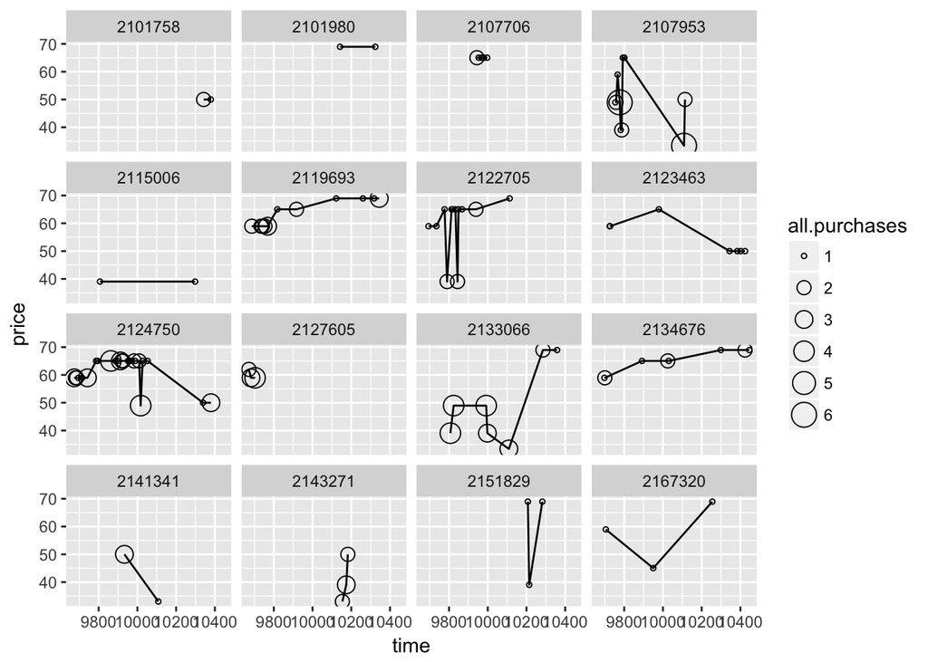

```r
# set the seed for reproducible results, if you use the same seed number you will get always the same households
set.seed(4230)
# getting a sample of 16 households, we are sampling from levels (of factors) because those are all the different housholds that I have
sample.ids <- sample(levels(yo$id), 16)

# lets draw it
ggplot(aes(x = time, y = price),
       data = subset(yo, id %in% sample.ids)) +
  # to paint one graph per id
  facet_wrap(~ id) +
  geom_line() +
  # size of the point depending on the number of purchases
  # pch is shape and fill
  geom_point(aes(size = all.purchases), pch = 1)
```

### The Limits of Cross Sectional Data

Notes:

### Many Variables

Notes: We should let the data speak to determine variables of interest. There´s a tool we can use to create a number of scatter plots automatically: a scatterplot matrix. In a scatterplot matrix there is a grid of scatter plots between any par of variables. Scatter plots are great but not necessarily suitable for any kind of variables like categorical ones.In these cases box plots or histograms are better.

### Scatterplot Matrices

Notes: We use the GGally to create scatterplot matrices

```r
#install.packages('GGally')
library(GGally)
theme_set(theme_minimal(20))

#set the seed for reproducible results, we are not using categorical variables
set.seed(1836)
#pf_subset <- pf[, c(2:15)] see notes below
pf_subset = pf[, c('age', 'dob_year', 'dob_month', 'gender', 'tenure')]
names(pf_subset)
```

```
## [1] "age"       "dob_year"  "dob_month" "gender"    "tenure"
```

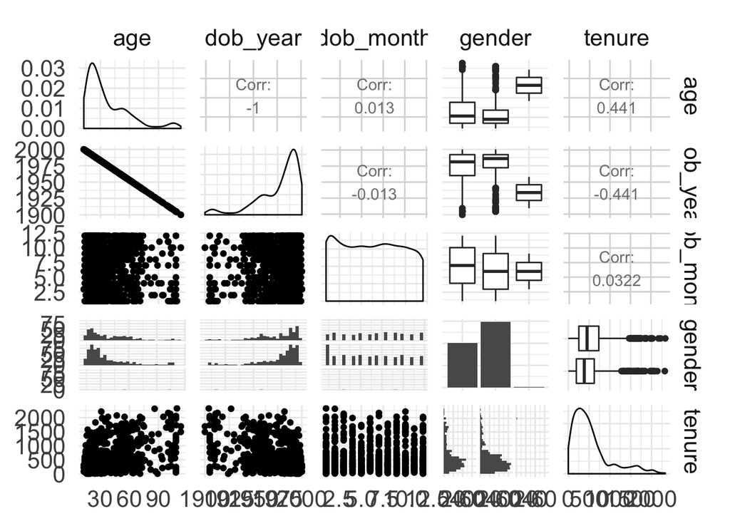

```r
ggpairs(pf_subset[sample.int(nrow(pf_subset), 1000),])
```

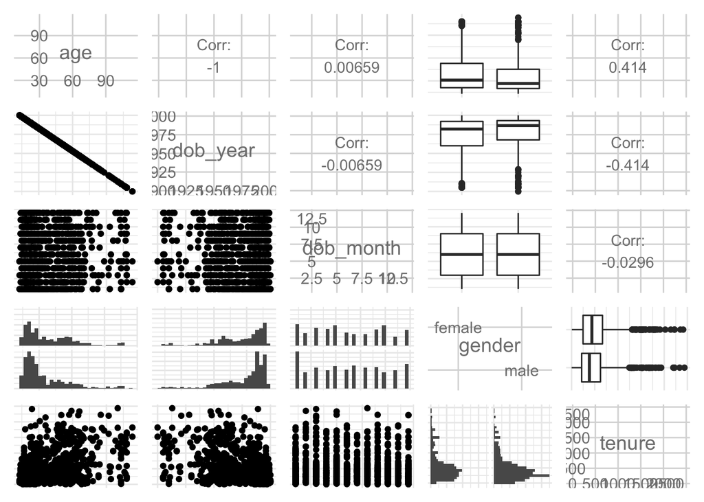

```r
ggpairs(pf_subset[sample.int(nrow(pf_subset), 1000),], axisLabels = 'internal')
```

If the code takes a while: You can use the following code or select fewer variables. We recommend including gender (the 6th variable)!

pf_subset = pf[, c(‘age’, ‘dob_year’, ‘dob_month’, ‘gender’, ‘tenure’)]

You can also select a subset using the subset() function and the “select” argument:

pf_subset <- subset(pf, select = -c(userid, year_joined, year_joined_bucket))

The - sign in the “select” value indicates all but the listed columns.

You may find in your matrix that variable labels are on the outer edges of the scatterplot matrix, rather than on the diagonal. If you want labels in the diagonal, you can set the axisLabels = ‘internal’ argument in your ggpairs command.

Scatterplot matrices uses depending on the variables: histograms, boxplots, satterplots. They are not fine tuned but it is really helpful to observe relationships between them. ***

### Even More Variables

Notes: A matrix like this is really usefull when we have even more variables, like genomic data.For a small number of samples there are thousands of variables.

### Heat Maps

Notes: Using genomic data.

```r
nci <- read.table("nci.tsv")
# change the colnames to produce a nicer plot
colnames(nci)
```

```
##  [1] "V1"  "V2"  "V3"  "V4"  "V5"  "V6"  "V7"  "V8"  "V9"  "V10" "V11"
## [12] "V12" "V13" "V14" "V15" "V16" "V17" "V18" "V19" "V20" "V21" "V22"
## [23] "V23" "V24" "V25" "V26" "V27" "V28" "V29" "V30" "V31" "V32" "V33"
## [34] "V34" "V35" "V36" "V37" "V38" "V39" "V40" "V41" "V42" "V43" "V44"
## [45] "V45" "V46" "V47" "V48" "V49" "V50" "V51" "V52" "V53" "V54" "V55"
## [56] "V56" "V57" "V58" "V59" "V60" "V61" "V62" "V63" "V64"
```

```r
#colnames(nci) <- c(1:64)
str(nci)
```

```
## 'data.frame':    6830 obs. of  64 variables:
##  $ V1 : num  0.3 1.18 0.55 1.14 -0.265 ...
##  $ V2 : num  0.68 1.29 0.17 0.38 0.465 ...
##  $ V3 : num  0.94 -0.04 -0.17 -0.04 -0.605 ...
##  $ V4 : num  0.28 -0.31 0.68 -0.81 0.625 ...
##  $ V5 : num  0.485 -0.465 0.395 0.905 0.2 ...
##  $ V6 : num  0.31 -0.03 -0.1 -0.46 -0.205 ...
##  $ V7 : num  -0.83 0 0.13 -1.63 0.075 ...
##  $ V8 : num  -0.19 -0.87 -0.45 0.08 0.005 ...
##  $ V9 : num  0.46 0 1.15 -1.4 -0.005 ...
##  $ V10: num  0.76 1.49 0.28 0.1 -0.525 ...
##  $ V11: num  0.27 0.63 -0.36 -1.04 0.015 ...
##  $ V12: num  -0.45 -0.06 0.15 -0.61 -0.395 ...
##  $ V13: num  -0.03 -1.12 -0.05 0 -0.285 ...
##  $ V14: num  0.71 0 0.16 -0.77 0.045 ...
```

[output cut: 50 more lines]

```r
# we can see nci is in wide format
```

We want to see for each combination of gene and sample, the difference in gene expression and the sample from the base line. Combinations where a gene is over expressed in red and underexpressed in blue.

Using (melt)[https://www.r-bloggers.com/melt/] function to change from wide to long format.

```r
library(reshape2)

# melt data to long format
# The melt function takes data in wide format and stacks a set of columns into a single column of data. To make use of the function we need to specify a data frame, the id variables (which will be left at their settings) and the measured variables (columns of data) to be stacked. The default assumption on measured variables is that it is all columns that are not specified as id variables.

nci.long.samp <- melt(as.matrix(nci[1:200,]))
names(nci.long.samp) <- c("case", "gene", "value")
head(nci.long.samp)
```

```
##   case gene  value
## 1    1   V1  0.300
## 2    2   V1  1.180
## 3    3   V1  0.550
## 4    4   V1  1.140
## 5    5   V1 -0.265
## 6    6   V1 -0.070
```

```r
# we obtain a long format
```

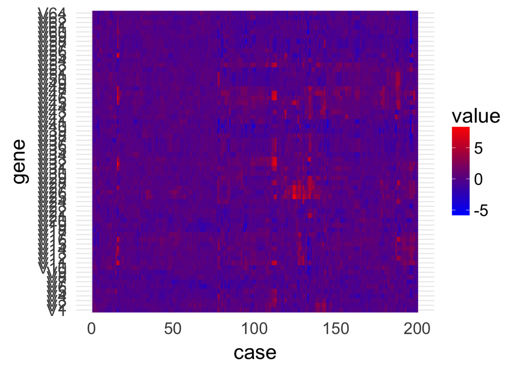

```r
# make the heatmap
ggplot(aes(y = gene, x = case, fill = value),
  data = nci.long.samp) +
  geom_tile() +
  # give us a scale gradient
  scale_fill_gradientn(colours = colorRampPalette(c("blue", "red"))(100))
```

### Analyzing Three of More Variables

Reflection:

Click **KnitHTML** to see all of your hard work and to have an html page of this lesson, your answers, and your notes!